# Risk Factor Analysis

## Outcome Variable

**Outcome Variable:** y_rate_len

## Predictor Variables

**Intervention Variable:** nchldlt5

**Adjustment Set:**

unadjusted

## Stratifying Variables

The analysis was stratified on these variable(s):

- agecat
- studyid
- country

## Data Summary

| agecat | studyid | country | nchldlt5 | n_cell | n |
| --- | --- | --- | --- | --- | --- |
| 0-3 months | IRC | INDIA | 1 | 82 | 377 |
| 0-3 months | IRC | INDIA | 2+ | 295 | 377 |
| 0-3 months | JiVitA-3 | BANGLADESH | 1 | 12370 | 19860 |
| 0-3 months | JiVitA-3 | BANGLADESH | 2+ | 7490 | 19860 |
| 0-3 months | NIH-Crypto | BANGLADESH | 1 | 512 | 721 |
| 0-3 months | NIH-Crypto | BANGLADESH | 2+ | 209 | 721 |
| 0-3 months | PROVIDE | BANGLADESH | 1 | 471 | 640 |
| 0-3 months | PROVIDE | BANGLADESH | 2+ | 169 | 640 |
| 3-6 months | IRC | INDIA | 1 | 87 | 397 |
| 3-6 months | IRC | INDIA | 2+ | 310 | 397 |
| 3-6 months | JiVitA-3 | BANGLADESH | 1 | 8103 | 12572 |
| 3-6 months | JiVitA-3 | BANGLADESH | 2+ | 4469 | 12572 |
| 3-6 months | NIH-Crypto | BANGLADESH | 1 | 492 | 695 |
| 3-6 months | NIH-Crypto | BANGLADESH | 2+ | 203 | 695 |
| 3-6 months | PROVIDE | BANGLADESH | 1 | 434 | 598 |
| 3-6 months | PROVIDE | BANGLADESH | 2+ | 164 | 598 |
| 3-6 months | TanzaniaChild2 | TANZANIA, UNITED REPUBLIC OF | 1 | 1146 | 1656 |
| 3-6 months | TanzaniaChild2 | TANZANIA, UNITED REPUBLIC OF | 2+ | 510 | 1656 |
| 6-9 months | IRC | INDIA | 1 | 89 | 407 |
| 6-9 months | IRC | INDIA | 2+ | 318 | 407 |
| 6-9 months | LCNI-5 | MALAWI | 1 | 261 | 557 |
| 6-9 months | LCNI-5 | MALAWI | 2+ | 296 | 557 |
| 6-9 months | NIH-Crypto | BANGLADESH | 1 | 488 | 688 |
| 6-9 months | NIH-Crypto | BANGLADESH | 2+ | 200 | 688 |
| 6-9 months | PROVIDE | BANGLADESH | 1 | 410 | 565 |
| 6-9 months | PROVIDE | BANGLADESH | 2+ | 155 | 565 |
| 6-9 months | TanzaniaChild2 | TANZANIA, UNITED REPUBLIC OF | 1 | 1036 | 1480 |
| 6-9 months | TanzaniaChild2 | TANZANIA, UNITED REPUBLIC OF | 2+ | 444 | 1480 |
| 9-12 months | iLiNS-Zinc | BURKINA FASO | 1 | 364 | 1101 |
| 9-12 months | iLiNS-Zinc | BURKINA FASO | 2+ | 737 | 1101 |

[output cut: 52 more lines]

The following strata were considered:

- agecat: 0-3 months, studyid: IRC, country: INDIA
- agecat: 0-3 months, studyid: JiVitA-3, country: BANGLADESH
- agecat: 0-3 months, studyid: NIH-Crypto, country: BANGLADESH
- agecat: 0-3 months, studyid: PROVIDE, country: BANGLADESH
- agecat: 12-15 months, studyid: iLiNS-Zinc, country: BURKINA FASO
- agecat: 12-15 months, studyid: IRC, country: INDIA
- agecat: 12-15 months, studyid: LCNI-5, country: MALAWI
- agecat: 12-15 months, studyid: NIH-Crypto, country: BANGLADESH
- agecat: 12-15 months, studyid: PROVIDE, country: BANGLADESH
- agecat: 12-15 months, studyid: TanzaniaChild2, country: TANZANIA, UNITED REPUBLIC OF
- agecat: 15-18 months, studyid: iLiNS-Zinc, country: BURKINA FASO
- agecat: 15-18 months, studyid: IRC, country: INDIA
- agecat: 15-18 months, studyid: LCNI-5, country: MALAWI
- agecat: 15-18 months, studyid: NIH-Crypto, country: BANGLADESH
- agecat: 15-18 months, studyid: PROVIDE, country: BANGLADESH
- agecat: 15-18 months, studyid: TanzaniaChild2, country: TANZANIA, UNITED REPUBLIC OF
- agecat: 18-21 months, studyid: IRC, country: INDIA
- agecat: 18-21 months, studyid: LCNI-5, country: MALAWI
- agecat: 18-21 months, studyid: NIH-Crypto, country: BANGLADESH
- agecat: 18-21 months, studyid: PROVIDE, country: BANGLADESH
- agecat: 18-21 months, studyid: TanzaniaChild2, country: TANZANIA, UNITED REPUBLIC OF
- agecat: 21-24 months, studyid: IRC, country: INDIA
- agecat: 21-24 months, studyid: LCNI-5, country: MALAWI
- agecat: 21-24 months, studyid: NIH-Crypto, country: BANGLADESH
- agecat: 21-24 months, studyid: PROVIDE, country: BANGLADESH
- agecat: 3-6 months, studyid: IRC, country: INDIA
- agecat: 3-6 months, studyid: JiVitA-3, country: BANGLADESH
- agecat: 3-6 months, studyid: NIH-Crypto, country: BANGLADESH
- agecat: 3-6 months, studyid: PROVIDE, country: BANGLADESH
- agecat: 3-6 months, studyid: TanzaniaChild2, country: TANZANIA, UNITED REPUBLIC OF
- agecat: 6-9 months, studyid: IRC, country: INDIA
- agecat: 6-9 months, studyid: LCNI-5, country: MALAWI
- agecat: 6-9 months, studyid: NIH-Crypto, country: BANGLADESH
- agecat: 6-9 months, studyid: PROVIDE, country: BANGLADESH
- agecat: 6-9 months, studyid: TanzaniaChild2, country: TANZANIA, UNITED REPUBLIC OF
- agecat: 9-12 months, studyid: iLiNS-Zinc, country: BURKINA FASO
- agecat: 9-12 months, studyid: IRC, country: INDIA
- agecat: 9-12 months, studyid: LCNI-5, country: MALAWI
- agecat: 9-12 months, studyid: NIH-Crypto, country: BANGLADESH
- agecat: 9-12 months, studyid: PROVIDE, country: BANGLADESH
- agecat: 9-12 months, studyid: TanzaniaChild2, country: TANZANIA, UNITED REPUBLIC OF

### Dropped Strata

Some strata were dropped due to rare outcomes:

- agecat: 18-21 months, studyid: TanzaniaChild2, country: TANZANIA, UNITED REPUBLIC OF

## Methods Detail

We’re interested in the causal parameters $E[Y_a]$ for all values of $a \in \mathcal{A}$. These parameters represent the mean outcome if, possibly contrary to fact, we intervened to set all units to have $A=a$. Under the randomization and positivity assumptions, these are identified by the statistical parameters $\psi_a=E_W[E_{Y|A,W}(Y|A=a,W)]$. In addition, we’re interested in the mean of $Y$, $E[Y]$ under no intervention (the observed mean). We will estimate these parameters by using SuperLearner to fit the relevant likelihood factors – $E_{Y|A,W}(Y|A=a,W)$ and $p(A=a|W)$, and then updating our likelihood fit using a joint TMLE.

For unadjusted analyses ($W=\{\}$), initial likelihoods were estimated using Lrnr_glm to estimate the simple $E(Y|A)$ and Lrnr_mean to estimate $p(A)$. For adjusted analyses, a small library containing Lrnr_glmnet, Lrnr_xgboost, and Lrnr_mean was used.

Having estimated these parameters, we will then use the delta method to estimate relative risks and attributable risks relative to a prespecified baseline level of $A$.

# Results Detail

## Results Plots

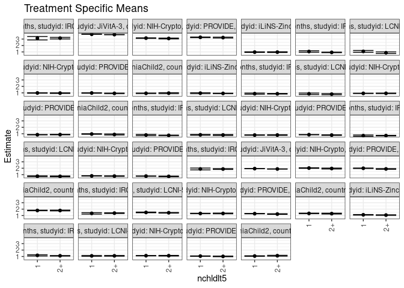

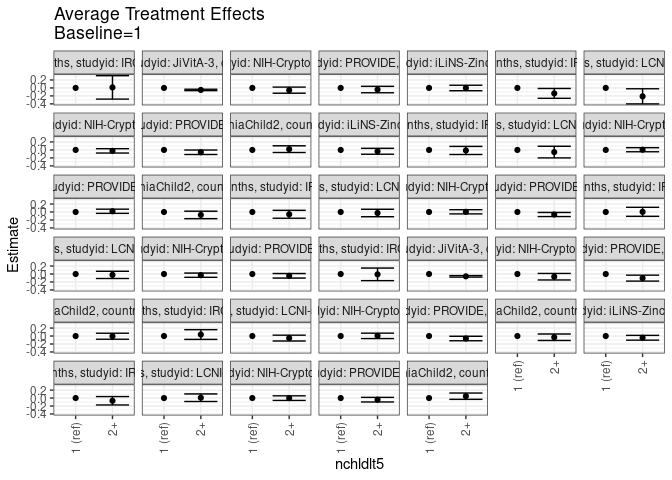

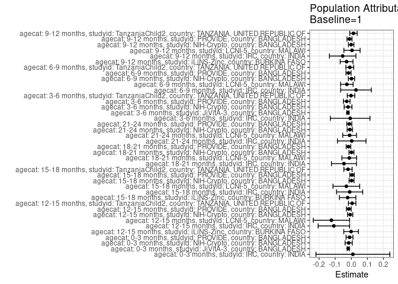

## Results Table

### Parameter: TSM

| agecat | studyid | country | intervention_level | baseline_level | estimate | ci_lower | ci_upper |
| --- | --- | --- | --- | --- | --- | --- | --- |
| 0-3 months | IRC | INDIA | 1 | NA | 3.1281019 | 2.8603411 | 3.3958628 |
| 0-3 months | IRC | INDIA | 2+ | NA | 3.1410699 | 3.0207246 | 3.2614152 |
| 0-3 months | JiVitA-3 | BANGLADESH | 1 | NA | 3.7424999 | 3.7303531 | 3.7546467 |
| 0-3 months | JiVitA-3 | BANGLADESH | 2+ | NA | 3.6918837 | 3.6767925 | 3.7069749 |
| 0-3 months | NIH-Crypto | BANGLADESH | 1 | NA | 3.1453503 | 3.1010402 | 3.1896603 |
| 0-3 months | NIH-Crypto | BANGLADESH | 2+ | NA | 3.0897906 | 3.0270203 | 3.1525608 |
| 0-3 months | PROVIDE | BANGLADESH | 1 | NA | 3.2684594 | 3.2245413 | 3.3123775 |
| 0-3 months | PROVIDE | BANGLADESH | 2+ | NA | 3.2276419 | 3.1596182 | 3.2956656 |
| 3-6 months | IRC | INDIA | 1 | NA | 1.8874100 | 1.7469248 | 2.0278952 |
| 3-6 months | IRC | INDIA | 2+ | NA | 1.8787834 | 1.8072244 | 1.9503423 |
| 3-6 months | JiVitA-3 | BANGLADESH | 1 | NA | 1.9410879 | 1.9284752 | 1.9537007 |
| 3-6 months | JiVitA-3 | BANGLADESH | 2+ | NA | 1.8824436 | 1.8662754 | 1.8986118 |
| 3-6 months | NIH-Crypto | BANGLADESH | 1 | NA | 2.0255186 | 1.9832633 | 2.0677739 |
| 3-6 months | NIH-Crypto | BANGLADESH | 2+ | NA | 1.9579998 | 1.8873043 | 2.0286952 |
| 3-6 months | PROVIDE | BANGLADESH | 1 | NA | 1.9940987 | 1.9542095 | 2.0339879 |
| 3-6 months | PROVIDE | BANGLADESH | 2+ | NA | 1.8907141 | 1.8279734 | 1.9534548 |
| 3-6 months | TanzaniaChild2 | TANZANIA, UNITED REPUBLIC OF | 1 | NA | 1.7947853 | 1.7507979 | 1.8387727 |
| 3-6 months | TanzaniaChild2 | TANZANIA, UNITED REPUBLIC OF | 2+ | NA | 1.7900061 | 1.7288426 | 1.8511695 |
| 6-9 months | IRC | INDIA | 1 | NA | 1.3430412 | 1.2337180 | 1.4523645 |
| 6-9 months | IRC | INDIA | 2+ | NA | 1.3806180 | 1.3264840 | 1.4347519 |
| 6-9 months | LCNI-5 | MALAWI | 1 | NA | 1.4891401 | 1.4341252 | 1.5441550 |
| 6-9 months | LCNI-5 | MALAWI | 2+ | NA | 1.4373452 | 1.3890619 | 1.4856284 |
| 6-9 months | NIH-Crypto | BANGLADESH | 1 | NA | 1.3269777 | 1.2931008 | 1.3608545 |
| 6-9 months | NIH-Crypto | BANGLADESH | 2+ | NA | 1.3314216 | 1.2729093 | 1.3899338 |
| 6-9 months | PROVIDE | BANGLADESH | 1 | NA | 1.2995434 | 1.2701731 | 1.3289137 |
| 6-9 months | PROVIDE | BANGLADESH | 2+ | NA | 1.2371204 | 1.1885813 | 1.2856595 |
| 6-9 months | TanzaniaChild2 | TANZANIA, UNITED REPUBLIC OF | 1 | NA | 1.3340980 | 1.2909333 | 1.3772626 |
| 6-9 months | TanzaniaChild2 | TANZANIA, UNITED REPUBLIC OF | 2+ | NA | 1.3037486 | 1.2348862 | 1.3726109 |
| 9-12 months | iLiNS-Zinc | BURKINA FASO | 1 | NA | 1.1207730 | 1.0780290 | 1.1635170 |
| 9-12 months | iLiNS-Zinc | BURKINA FASO | 2+ | NA | 1.0773728 | 1.0321756 | 1.1225700 |
| 9-12 months | IRC | INDIA | 1 | NA | 1.1769214 | 1.0803686 | 1.2734741 |
| 9-12 months | IRC | INDIA | 2+ | NA | 1.1083983 | 1.0660538 | 1.1507429 |
| 9-12 months | LCNI-5 | MALAWI | 1 | NA | 1.0962020 | 1.0228236 | 1.1695804 |
| 9-12 months | LCNI-5 | MALAWI | 2+ | NA | 1.1048132 | 1.0449554 | 1.1646711 |
| 9-12 months | NIH-Crypto | BANGLADESH | 1 | NA | 1.1240447 | 1.0929173 | 1.1551722 |
| 9-12 months | NIH-Crypto | BANGLADESH | 2+ | NA | 1.1221133 | 1.0733047 | 1.1709219 |
| 9-12 months | PROVIDE | BANGLADESH | 1 | NA | 1.0609918 | 1.0286363 | 1.0933473 |
| 9-12 months | PROVIDE | BANGLADESH | 2+ | NA | 1.0202367 | 0.9723837 | 1.0680897 |
| 9-12 months | TanzaniaChild2 | TANZANIA, UNITED REPUBLIC OF | 1 | NA | 1.0719541 | 1.0331289 | 1.1107792 |
| 9-12 months | TanzaniaChild2 | TANZANIA, UNITED REPUBLIC OF | 2+ | NA | 1.1190296 | 1.0498786 | 1.1881805 |
| 12-15 months | iLiNS-Zinc | BURKINA FASO | 1 | NA | 0.9681630 | 0.9206609 | 1.0156651 |
| 12-15 months | iLiNS-Zinc | BURKINA FASO | 2+ | NA | 0.9666191 | 0.9115450 | 1.0216933 |
| 12-15 months | IRC | INDIA | 1 | NA | 1.0636763 | 0.9475334 | 1.1798192 |
| 12-15 months | IRC | INDIA | 2+ | NA | 0.9265149 | 0.8844875 | 0.9685422 |
| 12-15 months | LCNI-5 | MALAWI | 1 | NA | 1.0817895 | 0.9434351 | 1.2201440 |
| 12-15 months | LCNI-5 | MALAWI | 2+ | NA | 0.8704965 | 0.7397378 | 1.0012552 |
| 12-15 months | NIH-Crypto | BANGLADESH | 1 | NA | 0.9779565 | 0.9489591 | 1.0069540 |
| 12-15 months | NIH-Crypto | BANGLADESH | 2+ | NA | 0.9551177 | 0.9090953 | 1.0011400 |
| 12-15 months | PROVIDE | BANGLADESH | 1 | NA | 0.9750552 | 0.9438272 | 1.0062831 |
| 12-15 months | PROVIDE | BANGLADESH | 2+ | NA | 0.9173082 | 0.8706553 | 0.9639612 |
| 12-15 months | TanzaniaChild2 | TANZANIA, UNITED REPUBLIC OF | 1 | NA | 0.9264067 | 0.8836259 | 0.9691875 |
| 12-15 months | TanzaniaChild2 | TANZANIA, UNITED REPUBLIC OF | 2+ | NA | 0.9464934 | 0.8738873 | 1.0190995 |
| 15-18 months | iLiNS-Zinc | BURKINA FASO | 1 | NA | 0.9432090 | 0.8708808 | 1.0155373 |
| 15-18 months | iLiNS-Zinc | BURKINA FASO | 2+ | NA | 0.9097394 | 0.8726422 | 0.9468367 |
| 15-18 months | IRC | INDIA | 1 | NA | 0.8691409 | 0.7769657 | 0.9613161 |
| 15-18 months | IRC | INDIA | 2+ | NA | 0.8565508 | 0.8131145 | 0.8999871 |
| 15-18 months | LCNI-5 | MALAWI | 1 | NA | 0.8504223 | 0.7368826 | 0.9639620 |
| 15-18 months | LCNI-5 | MALAWI | 2+ | NA | 0.7966357 | 0.7047281 | 0.8885432 |
| 15-18 months | NIH-Crypto | BANGLADESH | 1 | NA | 0.9159101 | 0.8890069 | 0.9428133 |
| 15-18 months | NIH-Crypto | BANGLADESH | 2+ | NA | 0.9220064 | 0.8782251 | 0.9657877 |
| 15-18 months | PROVIDE | BANGLADESH | 1 | NA | 0.8513407 | 0.8226102 | 0.8800713 |
| 15-18 months | PROVIDE | BANGLADESH | 2+ | NA | 0.8692893 | 0.8256476 | 0.9129309 |
| 15-18 months | TanzaniaChild2 | TANZANIA, UNITED REPUBLIC OF | 1 | NA | 0.9574483 | 0.9079835 | 1.0069132 |
| 15-18 months | TanzaniaChild2 | TANZANIA, UNITED REPUBLIC OF | 2+ | NA | 0.8833962 | 0.8039784 | 0.9628139 |
| 18-21 months | IRC | INDIA | 1 | NA | 0.8053304 | 0.7155419 | 0.8951190 |
| 18-21 months | IRC | INDIA | 2+ | NA | 0.7472321 | 0.7051839 | 0.7892802 |
| 18-21 months | LCNI-5 | MALAWI | 1 | NA | 0.8331733 | 0.7727012 | 0.8936454 |
| 18-21 months | LCNI-5 | MALAWI | 2+ | NA | 0.8076524 | 0.7362787 | 0.8790262 |
| 18-21 months | NIH-Crypto | BANGLADESH | 1 | NA | 0.7965132 | 0.7693598 | 0.8236667 |
| 18-21 months | NIH-Crypto | BANGLADESH | 2+ | NA | 0.8008479 | 0.7555084 | 0.8461874 |
| 18-21 months | PROVIDE | BANGLADESH | 1 | NA | 0.8566738 | 0.8280484 | 0.8852991 |
| 18-21 months | PROVIDE | BANGLADESH | 2+ | NA | 0.7928723 | 0.7500891 | 0.8356554 |
| 21-24 months | IRC | INDIA | 1 | NA | 0.7054472 | 0.6009850 | 0.8099094 |
| 21-24 months | IRC | INDIA | 2+ | NA | 0.7092296 | 0.6656588 | 0.7528005 |
| 21-24 months | LCNI-5 | MALAWI | 1 | NA | 0.7604801 | 0.6922731 | 0.8286872 |
| 21-24 months | LCNI-5 | MALAWI | 2+ | NA | 0.7383703 | 0.6784903 | 0.7982503 |
| 21-24 months | NIH-Crypto | BANGLADESH | 1 | NA | 0.8084059 | 0.7789375 | 0.8378743 |
| 21-24 months | NIH-Crypto | BANGLADESH | 2+ | NA | 0.7787755 | 0.7346706 | 0.8228803 |
| 21-24 months | PROVIDE | BANGLADESH | 1 | NA | 0.7754363 | 0.7457732 | 0.8050993 |
| 21-24 months | PROVIDE | BANGLADESH | 2+ | NA | 0.7305371 | 0.6818725 | 0.7792017 |

### Parameter: E(Y)

| agecat | studyid | country | intervention_level | baseline_level | estimate | ci_lower | ci_upper |
| --- | --- | --- | --- | --- | --- | --- | --- |
| 0-3 months | IRC | INDIA | NA | NA | 3.1382493 | 3.0275242 | 3.2489743 |
| 0-3 months | JiVitA-3 | BANGLADESH | NA | NA | 3.7234105 | 3.7131018 | 3.7337192 |
| 0-3 months | NIH-Crypto | BANGLADESH | NA | NA | 3.1292449 | 3.0928504 | 3.1656393 |
| 0-3 months | PROVIDE | BANGLADESH | NA | NA | 3.2576810 | 3.2206777 | 3.2946843 |
| 3-6 months | IRC | INDIA | NA | NA | 1.8806738 | 1.8168757 | 1.9444719 |
| 3-6 months | JiVitA-3 | BANGLADESH | NA | NA | 1.9202415 | 1.9097813 | 1.9307016 |
| 3-6 months | NIH-Crypto | BANGLADESH | NA | NA | 2.0057973 | 1.9693775 | 2.0422170 |
| 3-6 months | PROVIDE | BANGLADESH | NA | NA | 1.9657457 | 1.9318660 | 1.9996254 |
| 3-6 months | TanzaniaChild2 | TANZANIA, UNITED REPUBLIC OF | NA | NA | 1.7933135 | 1.7575160 | 1.8291109 |
| 6-9 months | IRC | INDIA | NA | NA | 1.3724009 | 1.3237927 | 1.4210091 |
| 6-9 months | LCNI-5 | MALAWI | NA | NA | 1.4616153 | 1.4251800 | 1.4980507 |
| 6-9 months | NIH-Crypto | BANGLADESH | NA | NA | 1.3282695 | 1.2988292 | 1.3577098 |
| 6-9 months | PROVIDE | BANGLADESH | NA | NA | 1.2824185 | 1.2571827 | 1.3076542 |
| 6-9 months | TanzaniaChild2 | TANZANIA, UNITED REPUBLIC OF | NA | NA | 1.3249931 | 1.2883838 | 1.3616025 |
| 9-12 months | iLiNS-Zinc | BURKINA FASO | NA | NA | 1.0917213 | 1.0579961 | 1.1254464 |
| 9-12 months | IRC | INDIA | NA | NA | 1.1234734 | 1.0841051 | 1.1628417 |
| 9-12 months | LCNI-5 | MALAWI | NA | NA | 1.1007887 | 1.0539615 | 1.1476158 |
| 9-12 months | NIH-Crypto | BANGLADESH | NA | NA | 1.1234745 | 1.0972274 | 1.1497215 |
| 9-12 months | PROVIDE | BANGLADESH | NA | NA | 1.0499750 | 1.0230130 | 1.0769370 |
| 9-12 months | TanzaniaChild2 | TANZANIA, UNITED REPUBLIC OF | NA | NA | 1.0855731 | 1.0514671 | 1.1196792 |
| 12-15 months | iLiNS-Zinc | BURKINA FASO | NA | NA | 0.9671413 | 0.9257414 | 1.0085412 |
| 12-15 months | IRC | INDIA | NA | NA | 0.9553539 | 0.9137750 | 0.9969329 |
| 12-15 months | LCNI-5 | MALAWI | NA | NA | 0.9583944 | 0.8610293 | 1.0557595 |
| 12-15 months | NIH-Crypto | BANGLADESH | NA | NA | 0.9711395 | 0.9465805 | 0.9956985 |
| 12-15 months | PROVIDE | BANGLADESH | NA | NA | 0.9597501 | 0.9335899 | 0.9859102 |
| 12-15 months | TanzaniaChild2 | TANZANIA, UNITED REPUBLIC OF | NA | NA | 0.9319267 | 0.8950348 | 0.9688186 |
| 15-18 months | iLiNS-Zinc | BURKINA FASO | NA | NA | 0.9206852 | 0.8832466 | 0.9581239 |
| 15-18 months | IRC | INDIA | NA | NA | 0.8591216 | 0.8197594 | 0.8984837 |
| 15-18 months | LCNI-5 | MALAWI | NA | NA | 0.8198824 | 0.7480865 | 0.8916783 |
| 15-18 months | NIH-Crypto | BANGLADESH | NA | NA | 0.9177168 | 0.8947657 | 0.9406678 |
| 15-18 months | PROVIDE | BANGLADESH | NA | NA | 0.8560998 | 0.8320145 | 0.8801852 |
| 15-18 months | TanzaniaChild2 | TANZANIA, UNITED REPUBLIC OF | NA | NA | 0.9372014 | 0.8951355 | 0.9792674 |
| 18-21 months | IRC | INDIA | NA | NA | 0.7598022 | 0.7214752 | 0.7981291 |
| 18-21 months | LCNI-5 | MALAWI | NA | NA | 0.8206832 | 0.7740479 | 0.8673186 |
| 18-21 months | NIH-Crypto | BANGLADESH | NA | NA | 0.7977755 | 0.7744353 | 0.8211158 |
| 18-21 months | PROVIDE | BANGLADESH | NA | NA | 0.8393377 | 0.8153485 | 0.8633269 |
| 21-24 months | IRC | INDIA | NA | NA | 0.7084129 | 0.6674749 | 0.7493508 |
| 21-24 months | LCNI-5 | MALAWI | NA | NA | 0.7500561 | 0.7042548 | 0.7958575 |
| 21-24 months | NIH-Crypto | BANGLADESH | NA | NA | 0.7993353 | 0.7748026 | 0.8238681 |
| 21-24 months | PROVIDE | BANGLADESH | NA | NA | 0.7631391 | 0.7377453 | 0.7885328 |

### Parameter: ATE

| agecat | studyid | country | intervention_level | baseline_level | estimate | ci_lower | ci_upper |
| --- | --- | --- | --- | --- | --- | --- | --- |
| 0-3 months | IRC | INDIA | 1 | 1 | 0.0000000 | 0.0000000 | 0.0000000 |
| 0-3 months | IRC | INDIA | 2+ | 1 | 0.0129680 | -0.2805944 | 0.3065303 |
| 0-3 months | JiVitA-3 | BANGLADESH | 1 | 1 | 0.0000000 | 0.0000000 | 0.0000000 |
| 0-3 months | JiVitA-3 | BANGLADESH | 2+ | 1 | -0.0506162 | -0.0682826 | -0.0329498 |
| 0-3 months | NIH-Crypto | BANGLADESH | 1 | 1 | 0.0000000 | 0.0000000 | 0.0000000 |
| 0-3 months | NIH-Crypto | BANGLADESH | 2+ | 1 | -0.0555597 | -0.1323938 | 0.0212744 |
| 0-3 months | PROVIDE | BANGLADESH | 1 | 1 | 0.0000000 | 0.0000000 | 0.0000000 |
| 0-3 months | PROVIDE | BANGLADESH | 2+ | 1 | -0.0408175 | -0.1217868 | 0.0401518 |
| 3-6 months | IRC | INDIA | 1 | 1 | 0.0000000 | 0.0000000 | 0.0000000 |
| 3-6 months | IRC | INDIA | 2+ | 1 | -0.0086267 | -0.1662870 | 0.1490337 |
| 3-6 months | JiVitA-3 | BANGLADESH | 1 | 1 | 0.0000000 | 0.0000000 | 0.0000000 |
| 3-6 months | JiVitA-3 | BANGLADESH | 2+ | 1 | -0.0586443 | -0.0781182 | -0.0391704 |
| 3-6 months | NIH-Crypto | BANGLADESH | 1 | 1 | 0.0000000 | 0.0000000 | 0.0000000 |
| 3-6 months | NIH-Crypto | BANGLADESH | 2+ | 1 | -0.0675189 | -0.1498800 | 0.0148423 |
| 3-6 months | PROVIDE | BANGLADESH | 1 | 1 | 0.0000000 | 0.0000000 | 0.0000000 |
| 3-6 months | PROVIDE | BANGLADESH | 2+ | 1 | -0.1033847 | -0.1777321 | -0.0290372 |
| 3-6 months | TanzaniaChild2 | TANZANIA, UNITED REPUBLIC OF | 1 | 1 | 0.0000000 | 0.0000000 | 0.0000000 |
| 3-6 months | TanzaniaChild2 | TANZANIA, UNITED REPUBLIC OF | 2+ | 1 | -0.0047793 | -0.0801176 | 0.0705590 |
| 6-9 months | IRC | INDIA | 1 | 1 | 0.0000000 | 0.0000000 | 0.0000000 |
| 6-9 months | IRC | INDIA | 2+ | 1 | 0.0375767 | -0.0844153 | 0.1595687 |
| 6-9 months | LCNI-5 | MALAWI | 1 | 1 | 0.0000000 | 0.0000000 | 0.0000000 |
| 6-9 months | LCNI-5 | MALAWI | 2+ | 1 | -0.0517949 | -0.1249926 | 0.0214028 |
| 6-9 months | NIH-Crypto | BANGLADESH | 1 | 1 | 0.0000000 | 0.0000000 | 0.0000000 |
| 6-9 months | NIH-Crypto | BANGLADESH | 2+ | 1 | 0.0044439 | -0.0631677 | 0.0720555 |
| 6-9 months | PROVIDE | BANGLADESH | 1 | 1 | 0.0000000 | 0.0000000 | 0.0000000 |
| 6-9 months | PROVIDE | BANGLADESH | 2+ | 1 | -0.0624230 | -0.1191562 | -0.0056897 |
| 6-9 months | TanzaniaChild2 | TANZANIA, UNITED REPUBLIC OF | 1 | 1 | 0.0000000 | 0.0000000 | 0.0000000 |
| 6-9 months | TanzaniaChild2 | TANZANIA, UNITED REPUBLIC OF | 2+ | 1 | -0.0303494 | -0.1116218 | 0.0509231 |
| 9-12 months | iLiNS-Zinc | BURKINA FASO | 1 | 1 | 0.0000000 | 0.0000000 | 0.0000000 |
| 9-12 months | iLiNS-Zinc | BURKINA FASO | 2+ | 1 | -0.0434001 | -0.1035012 | 0.0167009 |
| 9-12 months | IRC | INDIA | 1 | 1 | 0.0000000 | 0.0000000 | 0.0000000 |
| 9-12 months | IRC | INDIA | 2+ | 1 | -0.0685230 | -0.1739531 | 0.0369070 |
| 9-12 months | LCNI-5 | MALAWI | 1 | 1 | 0.0000000 | 0.0000000 | 0.0000000 |
| 9-12 months | LCNI-5 | MALAWI | 2+ | 1 | 0.0086112 | -0.0860849 | 0.1033073 |
| 9-12 months | NIH-Crypto | BANGLADESH | 1 | 1 | 0.0000000 | 0.0000000 | 0.0000000 |
| 9-12 months | NIH-Crypto | BANGLADESH | 2+ | 1 | -0.0019315 | -0.0598209 | 0.0559580 |
| 9-12 months | PROVIDE | BANGLADESH | 1 | 1 | 0.0000000 | 0.0000000 | 0.0000000 |
| 9-12 months | PROVIDE | BANGLADESH | 2+ | 1 | -0.0407551 | -0.0985201 | 0.0170098 |
| 9-12 months | TanzaniaChild2 | TANZANIA, UNITED REPUBLIC OF | 1 | 1 | 0.0000000 | 0.0000000 | 0.0000000 |
| 9-12 months | TanzaniaChild2 | TANZANIA, UNITED REPUBLIC OF | 2+ | 1 | 0.0470755 | -0.0322293 | 0.1263803 |
| 12-15 months | iLiNS-Zinc | BURKINA FASO | 1 | 1 | 0.0000000 | 0.0000000 | 0.0000000 |
| 12-15 months | iLiNS-Zinc | BURKINA FASO | 2+ | 1 | -0.0015438 | -0.0702390 | 0.0671513 |
| 12-15 months | IRC | INDIA | 1 | 1 | 0.0000000 | 0.0000000 | 0.0000000 |
| 12-15 months | IRC | INDIA | 2+ | 1 | -0.1371615 | -0.2606745 | -0.0136484 |
| 12-15 months | LCNI-5 | MALAWI | 1 | 1 | 0.0000000 | 0.0000000 | 0.0000000 |
| 12-15 months | LCNI-5 | MALAWI | 2+ | 1 | -0.2112931 | -0.4016606 | -0.0209255 |
| 12-15 months | NIH-Crypto | BANGLADESH | 1 | 1 | 0.0000000 | 0.0000000 | 0.0000000 |
| 12-15 months | NIH-Crypto | BANGLADESH | 2+ | 1 | -0.0228389 | -0.0772347 | 0.0315570 |
| 12-15 months | PROVIDE | BANGLADESH | 1 | 1 | 0.0000000 | 0.0000000 | 0.0000000 |
| 12-15 months | PROVIDE | BANGLADESH | 2+ | 1 | -0.0577470 | -0.1138868 | -0.0016071 |
| 12-15 months | TanzaniaChild2 | TANZANIA, UNITED REPUBLIC OF | 1 | 1 | 0.0000000 | 0.0000000 | 0.0000000 |
| 12-15 months | TanzaniaChild2 | TANZANIA, UNITED REPUBLIC OF | 2+ | 1 | 0.0200867 | -0.0641857 | 0.1043592 |
| 15-18 months | iLiNS-Zinc | BURKINA FASO | 1 | 1 | 0.0000000 | 0.0000000 | 0.0000000 |
| 15-18 months | iLiNS-Zinc | BURKINA FASO | 2+ | 1 | -0.0334696 | -0.1077981 | 0.0408589 |
| 15-18 months | IRC | INDIA | 1 | 1 | 0.0000000 | 0.0000000 | 0.0000000 |
| 15-18 months | IRC | INDIA | 2+ | 1 | -0.0125901 | -0.1144870 | 0.0893068 |
| 15-18 months | LCNI-5 | MALAWI | 1 | 1 | 0.0000000 | 0.0000000 | 0.0000000 |
| 15-18 months | LCNI-5 | MALAWI | 2+ | 1 | -0.0537866 | -0.1998628 | 0.0922896 |
| 15-18 months | NIH-Crypto | BANGLADESH | 1 | 1 | 0.0000000 | 0.0000000 | 0.0000000 |
| 15-18 months | NIH-Crypto | BANGLADESH | 2+ | 1 | 0.0060963 | -0.0452903 | 0.0574829 |
| 15-18 months | PROVIDE | BANGLADESH | 1 | 1 | 0.0000000 | 0.0000000 | 0.0000000 |
| 15-18 months | PROVIDE | BANGLADESH | 2+ | 1 | 0.0179485 | -0.0343013 | 0.0701983 |
| 15-18 months | TanzaniaChild2 | TANZANIA, UNITED REPUBLIC OF | 1 | 1 | 0.0000000 | 0.0000000 | 0.0000000 |
| 15-18 months | TanzaniaChild2 | TANZANIA, UNITED REPUBLIC OF | 2+ | 1 | -0.0740522 | -0.1676147 | 0.0195104 |
| 18-21 months | IRC | INDIA | 1 | 1 | 0.0000000 | 0.0000000 | 0.0000000 |
| 18-21 months | IRC | INDIA | 2+ | 1 | -0.0580984 | -0.1572449 | 0.0410481 |
| 18-21 months | LCNI-5 | MALAWI | 1 | 1 | 0.0000000 | 0.0000000 | 0.0000000 |
| 18-21 months | LCNI-5 | MALAWI | 2+ | 1 | -0.0255208 | -0.1190681 | 0.0680264 |
| 18-21 months | NIH-Crypto | BANGLADESH | 1 | 1 | 0.0000000 | 0.0000000 | 0.0000000 |
| 18-21 months | NIH-Crypto | BANGLADESH | 2+ | 1 | 0.0043347 | -0.0485139 | 0.0571834 |
| 18-21 months | PROVIDE | BANGLADESH | 1 | 1 | 0.0000000 | 0.0000000 | 0.0000000 |
| 18-21 months | PROVIDE | BANGLADESH | 2+ | 1 | -0.0638015 | -0.1152778 | -0.0123252 |
| 21-24 months | IRC | INDIA | 1 | 1 | 0.0000000 | 0.0000000 | 0.0000000 |
| 21-24 months | IRC | INDIA | 2+ | 1 | 0.0037825 | -0.1094022 | 0.1169671 |
| 21-24 months | LCNI-5 | MALAWI | 1 | 1 | 0.0000000 | 0.0000000 | 0.0000000 |
| 21-24 months | LCNI-5 | MALAWI | 2+ | 1 | -0.0221098 | -0.1128722 | 0.0686526 |
| 21-24 months | NIH-Crypto | BANGLADESH | 1 | 1 | 0.0000000 | 0.0000000 | 0.0000000 |
| 21-24 months | NIH-Crypto | BANGLADESH | 2+ | 1 | -0.0296304 | -0.0826740 | 0.0234132 |
| 21-24 months | PROVIDE | BANGLADESH | 1 | 1 | 0.0000000 | 0.0000000 | 0.0000000 |
| 21-24 months | PROVIDE | BANGLADESH | 2+ | 1 | -0.0448991 | -0.1018916 | 0.0120933 |

### Parameter: PAR

| agecat | studyid | country | intervention_level | baseline_level | estimate | ci_lower | ci_upper |
| --- | --- | --- | --- | --- | --- | --- | --- |
| 0-3 months | IRC | INDIA | 1 | NA | 0.0101474 | -0.2195639 | 0.2398586 |
| 0-3 months | JiVitA-3 | BANGLADESH | 1 | NA | -0.0190894 | -0.0257547 | -0.0124241 |
| 0-3 months | NIH-Crypto | BANGLADESH | 1 | NA | -0.0161054 | -0.0384537 | 0.0062429 |
| 0-3 months | PROVIDE | BANGLADESH | 1 | NA | -0.0107784 | -0.0322048 | 0.0106481 |
| 3-6 months | IRC | INDIA | 1 | NA | -0.0067362 | -0.1298468 | 0.1163744 |
| 3-6 months | JiVitA-3 | BANGLADESH | 1 | NA | -0.0208464 | -0.0277805 | -0.0139124 |
| 3-6 months | NIH-Crypto | BANGLADESH | 1 | NA | -0.0197213 | -0.0438861 | 0.0044434 |
| 3-6 months | PROVIDE | BANGLADESH | 1 | NA | -0.0283530 | -0.0490755 | -0.0076304 |
| 3-6 months | TanzaniaChild2 | TANZANIA, UNITED REPUBLIC OF | 1 | NA | -0.0014719 | -0.0246741 | 0.0217304 |
| 6-9 months | IRC | INDIA | 1 | NA | 0.0293597 | -0.0659679 | 0.1246873 |
| 6-9 months | LCNI-5 | MALAWI | 1 | NA | -0.0275248 | -0.0664827 | 0.0114331 |
| 6-9 months | NIH-Crypto | BANGLADESH | 1 | NA | 0.0012918 | -0.0183633 | 0.0209469 |
| 6-9 months | PROVIDE | BANGLADESH | 1 | NA | -0.0171249 | -0.0328577 | -0.0013921 |
| 6-9 months | TanzaniaChild2 | TANZANIA, UNITED REPUBLIC OF | 1 | NA | -0.0091048 | -0.0334968 | 0.0152872 |
| 9-12 months | iLiNS-Zinc | BURKINA FASO | 1 | NA | -0.0290517 | -0.0688028 | 0.0106994 |
| 9-12 months | IRC | INDIA | 1 | NA | -0.0534480 | -0.1357306 | 0.0288346 |
| 9-12 months | LCNI-5 | MALAWI | 1 | NA | 0.0045867 | -0.0458539 | 0.0550272 |
| 9-12 months | NIH-Crypto | BANGLADESH | 1 | NA | -0.0005703 | -0.0176624 | 0.0165219 |
| 9-12 months | PROVIDE | BANGLADESH | 1 | NA | -0.0110168 | -0.0267029 | 0.0046692 |
| 9-12 months | TanzaniaChild2 | TANZANIA, UNITED REPUBLIC OF | 1 | NA | 0.0136191 | -0.0093595 | 0.0365976 |
| 12-15 months | iLiNS-Zinc | BURKINA FASO | 1 | NA | -0.0010217 | -0.0464856 | 0.0444422 |
| 12-15 months | IRC | INDIA | 1 | NA | -0.1083224 | -0.2060241 | -0.0106207 |
| 12-15 months | LCNI-5 | MALAWI | 1 | NA | -0.1233951 | -0.2360708 | -0.0107195 |
| 12-15 months | NIH-Crypto | BANGLADESH | 1 | NA | -0.0068171 | -0.0230730 | 0.0094389 |
| 12-15 months | PROVIDE | BANGLADESH | 1 | NA | -0.0153051 | -0.0303414 | -0.0002689 |
| 12-15 months | TanzaniaChild2 | TANZANIA, UNITED REPUBLIC OF | 1 | NA | 0.0055200 | -0.0176473 | 0.0286874 |
| 15-18 months | iLiNS-Zinc | BURKINA FASO | 1 | NA | -0.0225238 | -0.0735307 | 0.0284831 |
| 15-18 months | IRC | INDIA | 1 | NA | -0.0100193 | -0.0911116 | 0.0710730 |
| 15-18 months | LCNI-5 | MALAWI | 1 | NA | -0.0305399 | -0.1136218 | 0.0525421 |
| 15-18 months | NIH-Crypto | BANGLADESH | 1 | NA | 0.0018067 | -0.0134238 | 0.0170371 |
| 15-18 months | PROVIDE | BANGLADESH | 1 | NA | 0.0047591 | -0.0091115 | 0.0186297 |
| 15-18 months | TanzaniaChild2 | TANZANIA, UNITED REPUBLIC OF | 1 | NA | -0.0202469 | -0.0459516 | 0.0054579 |
| 18-21 months | IRC | INDIA | 1 | NA | -0.0455283 | -0.1232610 | 0.0322044 |
| 18-21 months | LCNI-5 | MALAWI | 1 | NA | -0.0124901 | -0.0582872 | 0.0333071 |
| 18-21 months | NIH-Crypto | BANGLADESH | 1 | NA | 0.0012623 | -0.0141286 | 0.0166532 |
| 18-21 months | PROVIDE | BANGLADESH | 1 | NA | -0.0173361 | -0.0315265 | -0.0031456 |
| 21-24 months | IRC | INDIA | 1 | NA | 0.0029657 | -0.0857782 | 0.0917096 |
| 21-24 months | LCNI-5 | MALAWI | 1 | NA | -0.0104240 | -0.0532288 | 0.0323808 |
| 21-24 months | NIH-Crypto | BANGLADESH | 1 | NA | -0.0090705 | -0.0253534 | 0.0072124 |
| 21-24 months | PROVIDE | BANGLADESH | 1 | NA | -0.0122972 | -0.0280112 | 0.0034168 |